# SS82

Talking to Bruno about his project on stacking Swift observations and my project on Stripe82 SED we started to think about a collaboration to create a set of deep observations with Swift data. Deep Swift data being a great addition to the High-Energy end of Stripe82 data collection (see, for instance, [LaMassa,2016](http://adsabs.harvard.edu/cgi-bin/bib_query?arXiv:1510.00852)).

Bruno then seached for all Swift-XRT observations inside the Stripe-82:

- RA: 310 : 60
- Dec: -1.25 : 1.25

Over the Stripe, Bruno has found ~3000 observations. See `Figure 1` and tables `Table 1` and `Table 2`.

If all you want is to have a look at the final/filtered catalog, go straight to final section. Otherwise, if the code used in this filtering does matter to you, you can show them out clicking the button below.

```python
from IPython.display import HTML

HTML('''<script>
code_show=true;
function code_toggle() {
 if (code_show){
 $('div.input').hide();
 } else {
 $('div.input').show();
 }
 code_show = !code_show
}
$( document ).ready(code_toggle);
</script>
<form action="javascript:code_toggle()"><input type="submit" value="Click here to toggle on/off the raw code."></form>''')
```

```python
from IPython.display import HTML
HTML('''
<figure>
  <img src="Stripe82_gal_projection.png" alt="Swift observations over Stripe82">
  <figcaption>Figure 1: Swift observations over Stripe82</figcaption>
</figure>
''')
```

[figure not shown]

Figure 1: Swift observations over Stripe82

## The base catalog

Right below, in `Table 1`, we can see a sample of the catalog (the first/last five lines).

In `Table 2`, we see a brief description of the catalog.

```python
import pandas
cat = pandas.read_csv('Swift_Master_Stripe82_groups.ascii',
                     delim_whitespace=True)
```

```python
print "Table 1: Sample of the catalog"
pandas.concat([cat.head(5),cat.tail(5)])
```

```
Table 1: Sample of the catalog
```

|  | Target_Name | obsid | RA_(J2000) | Dec_(J2000) | start_time | processing_date | xrt_exposure | uvot_exposure | bat_exposure | archive_date | Eclip_LONG | Eclip_LAT | GroupID | GroupSize |
| --- | --- | --- | --- | --- | --- | --- | --- | --- | --- | --- | --- | --- | --- | --- |
| 0 | SAA-COLD-185-05 | 74146019 | 59.95865 | 0.01190 | Jul 4, 2011 10:56:00 | Jul 10, 2011 | 43.606 | 0.000 | 213.000 | Jul 11, 2011 | 57.778385 | -20.129974 | 1.0 | 28.0 |
| 1 | SAA-COLD-78-07 | 74146024 | 59.97165 | -0.00647 | Mar 19, 2013 21:58:00 | Mar 29, 2013 | 59.618 | 0.000 | 103.000 | Mar 30, 2013 | 57.787768 | -20.150683 | 1.0 | 28.0 |
| 2 | SAA-COLD-184-06 | 74146006 | 59.97396 | -0.01571 | Jul 4, 2008 10:55:00 | Oct 14, 2015 | 142.730 | 0.000 | 288.000 | Jul 15, 2008 | 57.788085 | -20.160203 | 1.0 | 28.0 |
| 3 | SAA-COLD-184-06 | 74146028 | 59.97467 | -0.00349 | Jul 4, 2014 11:29:00 | Jul 14, 2014 | 73.495 | 0.000 | 328.000 | Jul 15, 2014 | 57.791585 | -20.148411 | 1.0 | 28.0 |
| 4 | SAA-COLD-77-07 | 74146026 | 59.97849 | 0.00060 | Mar 18, 2014 23:21:00 | Mar 28, 2014 | 72.428 | 0.000 | 160.000 | Mar 29, 2014 | 57.796485 | -20.145224 | 1.0 | 28.0 |
| 3030 | SWIFT_GAL_SURVE | 44610002 | 284.38862 | 1.09587 | Mar 22, 2013 13:23:00 | Apr 2, 2013 | 531.689 | 530.397 | 538.000 | Apr 2, 2013 | 285.750199 | 23.751873 | NaN | NaN |
| 3031 | 3FGLJ1903.9+005 | 84846001 | 285.97019 | 0.93181 | Nov 11, 2015 23:59:00 | Nov 22, 2015 | 2817.892 | 2949.033 | 2999.000 | Nov 22, 2015 | 287.444088 | 23.409176 | NaN | NaN |
| 3032 | BURST (292.702, | 680457000 | 292.70477 | -0.66809 | Mar 25, 2016 13:01:00 | Apr 4, 2016 | 5.078 | 0.000 | 2017.941 | Apr 5, 2016 | 294.396792 | 20.868780 | NaN | NaN |
| 3033 | GRB 131127B | 20329001 | 307.93677 | 0.98894 | Nov 28, 2013 10:08:00 | Dec 8, 2013 | 4976.248 | 4949.621 | 5005.000 | Dec 9, 2013 | 310.621610 | 19.239110 | NaN | NaN |
| 3034 | SWIFTJ2036.0-00 | 85659001 | 308.99192 | -0.46204 | Mar 16, 2016 07:25:00 | Mar 26, 2016 | 839.939 | 814.009 | 847.000 | Mar 27, 2016 | 311.296388 | 17.563196 | NaN | NaN |

```python
print "Table 2: Summary of the catalog columns"
cat.describe(include='all')
```

```
Table 2: Summary of the catalog columns
```

|  | Target_Name | obsid | RA_(J2000) | Dec_(J2000) | start_time | processing_date | xrt_exposure | uvot_exposure | bat_exposure | archive_date | Eclip_LONG | Eclip_LAT | GroupID | GroupSize |
| --- | --- | --- | --- | --- | --- | --- | --- | --- | --- | --- | --- | --- | --- | --- |
| count | 3035 | 3.035000e+03 | 3035.000000 | 3035.000000 | 3035 | 3035 | 3035.000000 | 3035.000000 | 3035.000000 | 3035 | 3035.000000 | 3035.000000 | 2879.000000 | 2879.000000 |
| unique | 681 | NaN | NaN | NaN | 3035 | 1397 | NaN | NaN | NaN | 1889 | NaN | NaN | NaN | NaN |
| top | AQLX-1 | NaN | NaN | NaN | Apr 15, 2006 16:15:00 | Oct 7, 2014 | NaN | NaN | NaN | May 2, 2016 | NaN | NaN | NaN | NaN |
| freq | 278 | NaN | NaN | NaN | 1 | 45 | NaN | NaN | NaN | 36 | NaN | NaN | NaN | NaN |
| mean | NaN | 1.558216e+08 | 186.316193 | 0.075929 | NaN | NaN | 1517.361663 | 1422.427248 | 1667.715949 | NaN | 186.696292 | 0.341681 | 128.784300 | 54.054533 |
| std | NaN | 7.351472e+08 | 75.843331 | 0.555652 | NaN | NaN | 2853.121293 | 2728.280131 | 2970.263464 | NaN | 76.034196 | 18.148077 | 77.159774 | 79.198817 |
| min | NaN | 2.029400e+07 | 59.958650 | -1.266100 | NaN | NaN | 0.000000 | 0.000000 | 0.000000 | NaN | 57.778385 | -24.655739 | 1.000000 | 2.000000 |
| 25% | NaN | 3.372302e+07 | 120.540790 | -0.164905 | NaN | NaN | 128.620000 | 0.000000 | 317.500000 | NaN | 122.565842 | -19.251349 | NaN | NaN |
| 50% | NaN | 6.801500e+07 | 177.673620 | 0.007210 | NaN | NaN | 686.995000 | 618.296000 | 890.000000 | NaN | 177.675042 | -1.338063 | NaN | NaN |
| 75% | NaN | 7.504200e+07 | 265.013060 | 0.572640 | NaN | NaN | 1742.863500 | 1695.957500 | 1805.000000 | NaN | 264.565893 | 19.920627 | NaN | NaN |
| max | NaN | 7.002534e+09 | 310.920870 | 1.269710 | NaN | NaN | 47281.003000 | 44578.666000 | 49097.000000 | NaN | 313.379440 | 24.695579 | 244.000000 | 280.000000 |

`Target_Name` is the name of the (central) object at each observation, from that we see we have 681 unique sources out of the 3035 observations. `GroupSize` is the number of overlapping observations, the average number is ~54. Let's see how sparse are the observations in time and how do they distribute for each source.

```python
cat['start_time'] = pandas.to_datetime(cat['start_time'])
```

```python
cat_grouped_by_target = cat[['Target_Name','start_time']].groupby(['Target_Name'])
```

```python
cat_descr = cat_grouped_by_target.describe().unstack()
cat_time = cat_descr.sort_values([('start_time','count')],ascending=False)
del cat_descr
```

### Number of observations

To have a glue about the number of observations done over each object we can look the counts shown by `Table 3` and the histogram below (`Figure 2`).

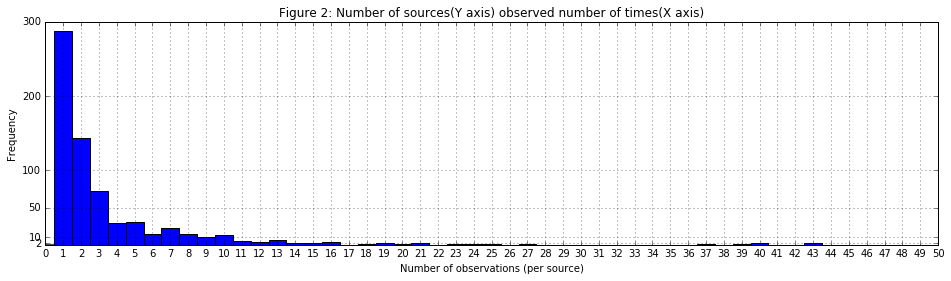

```python
title = "Figure 2: Number of sources(Y axis) observed number of times(X axis)"
%matplotlib inline
from matplotlib import pyplot as plt
width = 16
height = 4
plt.figure(figsize=(width, height))
yticks = [2,10,50,100,200,300]
xticks = range(51)
ax = cat_time[('start_time','count')].plot.hist(bins=xticks,xlim=(0,50),title=title,grid=True,xticks=xticks,yticks=yticks,align='left')
ax.set_xlabel('Number of observations (per source)')
```

```python
print "Table 3: Number counts and dates (first/last) of the observations (per object)"
cat_time
```

```
Table 3: Number counts and dates (first/last) of the observations (per object)
```

| Target_Name | start_time count | start_time unique | start_time top | start_time freq | start_time first | start_time last |
| --- | --- | --- | --- | --- | --- | --- |
| AQLX-1 | 278 | 278 | 2009-11-15 03:22:00 | 1 | 2006-03-07 00:16:00 | 2015-10-14 14:14:00 |
| PSRJ1023+0038 | 123 | 123 | 2016-01-07 00:40:00 | 1 | 2013-06-10 14:00:00 | 2016-06-08 03:51:00 |
| ARK120 | 87 | 87 | 2014-12-09 14:00:00 | 1 | 2014-03-22 10:23:00 | 2015-03-15 08:59:00 |
| SWIFT_GAL_SURVE | 77 | 77 | 2013-03-22 13:23:00 | 1 | 2011-02-25 11:01:00 | 2013-03-22 13:23:00 |
| SN2007AF | 55 | 55 | 2007-03-19 13:18:00 | 1 | 2007-03-02 19:14:00 | 2007-07-20 15:58:00 |
| PMNJ0948+0022 | 43 | 43 | 2012-06-18 12:03:00 | 1 | 2008-12-05 02:21:00 | 2016-06-13 23:59:00 |
| PS15AE | 43 | 43 | 2015-02-19 06:57:00 | 1 | 2015-02-19 06:57:00 | 2016-03-10 08:40:00 |
| 1ES0414+009 | 40 | 40 | 2012-11-08 07:56:00 | 1 | 2006-10-21 00:30:00 | 2016-02-05 02:54:00 |
| SA101 | 40 | 40 | 2009-06-30 18:48:00 | 1 | 2005-02-19 01:15:00 | 2015-11-17 00:20:00 |
| AEAQR | 39 | 39 | 2005-08-31 00:54:00 | 1 | 2005-08-30 18:56:00 | 2015-12-17 00:48:00 |
| ASASSN-15HY | 37 | 37 | 2015-05-02 18:52:00 | 1 | 2015-04-29 14:13:00 | 2015-06-23 11:17:00 |
| ASASSN-14LP | 27 | 27 | 2014-12-11 17:46:00 | 1 | 2014-12-10 09:35:00 | 2015-02-15 16:48:00 |
| SWIFTJ185003.2- | 25 | 25 | 2011-07-01 13:32:00 | 1 | 2011-06-24 23:50:00 | 2011-07-21 07:11:00 |
| GRB141109A | 24 | 24 | 2014-11-12 00:23:00 | 1 | 2014-11-09 05:34:00 | 2014-12-09 01:42:00 |
| ASASSN-16AT | 23 | 23 | 2016-02-06 23:59:00 | 1 | 2016-01-21 01:01:00 | 2016-03-05 07:56:00 |
| 2XMMJ185114.3-0 | 21 | 21 | 2012-06-19 17:17:00 | 1 | 2012-06-17 15:31:00 | 2012-08-31 14:59:00 |
| SAA-COLD-309-06 | 21 | 21 | 2008-02-02 08:11:00 | 1 | 2008-02-02 08:11:00 | 2016-02-03 10:07:00 |
| SAA-COLD-115-05 | 20 | 20 | 2016-05-01 20:45:00 | 1 | 2007-05-02 18:34:00 | 2016-05-01 20:45:00 |
| SAA-COLD-100-07 | 19 | 19 | 2008-08-21 09:18:00 | 1 | 2006-08-03 08:22:00 | 2015-08-05 09:34:00 |
| SA98OFFSET2 | 19 | 19 | 2014-05-15 07:07:00 | 1 | 2005-03-10 01:35:00 | 2016-04-23 21:08:00 |
| SA104SW | 18 | 18 | 2005-02-22 07:01:00 | 1 | 2005-02-22 07:01:00 | 2015-07-02 00:43:00 |
| SAA-COLD-261-07 | 16 | 16 | 2006-12-28 14:44:00 | 1 | 2006-09-07 20:50:00 | 2015-12-30 12:25:00 |
| SA104N | 16 | 16 | 2005-03-21 08:34:00 | 1 | 2005-03-10 10:06:00 | 2013-12-04 23:59:00 |
| 3XMMJ185246.9+0 | 16 | 16 | 2013-08-29 00:57:00 | 1 | 2012-09-25 06:49:00 | 2013-10-30 09:13:00 |
| SAA-COLD-254-05 | 16 | 16 | 2006-12-24 12:34:00 | 1 | 2006-08-21 20:50:00 | 2015-12-26 12:41:00 |
| SAA-COLD-228-05 | 15 | 15 | 2013-08-27 09:42:00 | 1 | 2006-08-16 11:25:00 | 2015-09-28 06:24:00 |
| UGC4179-SN06JD | 15 | 15 | 2012-09-14 16:56:00 | 1 | 2008-12-09 01:08:00 | 2013-02-02 09:03:00 |
| SAA-COLD-165-05 | 14 | 14 | 2011-06-11 17:28:00 | 1 | 2006-09-14 08:08:00 | 2015-09-22 06:52:00 |
| V1647ORI | 14 | 14 | 2010-03-05 06:36:00 | 1 | 2008-09-09 00:14:00 | 2015-01-09 12:52:00 |
| SA101OFFSET1 | 13 | 13 | 2009-07-01 17:15:00 | 1 | 2005-03-10 13:12:00 | 2016-05-16 16:27:00 |
| ... | ... | ... | ... | ... | ... | ... |
| Q1016-006 | 1 | 1 | 2015-10-19 07:03:00 | 1 | 2015-10-19 07:03:00 | 2015-10-19 07:03:00 |
| PKSB1130+008 | 1 | 1 | 2011-04-22 18:23:00 | 1 | 2011-04-22 18:23:00 | 2011-04-22 18:23:00 |
| PKS0422+00 | 1 | 1 | 2010-10-18 19:20:00 | 1 | 2010-10-18 19:20:00 | 2010-10-18 19:20:00 |
| OGP_3888 | 1 | 1 | 2016-05-21 00:04:00 | 1 | 2016-05-21 00:04:00 | 2016-05-21 00:04:00 |
| SAA-COLD-113-06 | 1 | 1 | 2013-04-23 20:12:00 | 1 | 2013-04-23 20:12:00 | 2013-04-23 20:12:00 |
| SAA-COLD-115-5 | 1 | 1 | 2010-04-25 17:40:00 | 1 | 2010-04-25 17:40:00 | 2010-04-25 17:40:00 |
| SAA-COLD-118-05 | 1 | 1 | 2012-04-27 18:19:00 | 1 | 2012-04-27 18:19:00 | 2012-04-27 18:19:00 |
| SAA-COLD-119-16 | 1 | 1 | 2009-04-29 22:25:00 | 1 | 2009-04-29 22:25:00 | 2009-04-29 22:25:00 |
| SAA-COLD-185-05 | 1 | 1 | 2011-07-04 10:56:00 | 1 | 2011-07-04 10:56:00 | 2011-07-04 10:56:00 |
| SAA-COLD-183-15 | 1 | 1 | 2006-07-02 11:19:00 | 1 | 2006-07-02 11:19:00 | 2006-07-02 11:19:00 |
| SAA-COLD-169-07 | 1 | 1 | 2015-06-18 18:55:00 | 1 | 2015-06-18 18:55:00 | 2015-06-18 18:55:00 |
| SAA-COLD-165-6 | 1 | 1 | 2006-06-14 19:34:00 | 1 | 2006-06-14 19:34:00 | 2006-06-14 19:34:00 |
| SAA-COLD-164-6 | 1 | 1 | 2006-06-13 19:27:00 | 1 | 2006-06-13 19:27:00 | 2006-06-13 19:27:00 |
| SAA-COLD-164-5 | 1 | 1 | 2010-06-13 17:29:00 | 1 | 2010-06-13 17:29:00 | 2010-06-13 17:29:00 |
| SAA-COLD-164-13 | 1 | 1 | 2009-06-13 18:44:00 | 1 | 2009-06-13 18:44:00 | 2009-06-13 18:44:00 |
| SAA-COLD-162-7 | 1 | 1 | 2005-06-11 20:23:00 | 1 | 2005-06-11 20:23:00 | 2005-06-11 20:23:00 |
| 1A 0535+262 | 1 | 1 | 2005-05-29 15:39:00 | 1 | 2005-05-29 15:39:00 | 2005-05-29 15:39:00 |
| SAA-COLD-159-13 | 1 | 1 | 2009-06-08 16:33:00 | 1 | 2009-06-08 16:33:00 | 2009-06-08 16:33:00 |
| SAA-COLD-158-6 | 1 | 1 | 2005-06-07 19:53:00 | 1 | 2005-06-07 19:53:00 | 2005-06-07 19:53:00 |
| SAA-COLD-158-5 | 1 | 1 | 2009-06-07 18:08:00 | 1 | 2009-06-07 18:08:00 | 2009-06-07 18:08:00 |
| SAA-COLD-156-14 | 1 | 1 | 2010-06-05 18:28:00 | 1 | 2010-06-05 18:28:00 | 2010-06-05 18:28:00 |
| SAA-COLD-154-5 | 1 | 1 | 2005-06-03 18:00:00 | 1 | 2005-06-03 18:00:00 | 2005-06-03 18:00:00 |
| SAA-COLD-146-5 | 1 | 1 | 2006-05-26 19:16:00 | 1 | 2006-05-26 19:16:00 | 2006-05-26 19:16:00 |
| SAA-COLD-145-6 | 1 | 1 | 2005-05-25 20:05:00 | 1 | 2005-05-25 20:05:00 | 2005-05-25 20:05:00 |
| SAA-COLD-144-5 | 1 | 1 | 2005-05-24 18:26:00 | 1 | 2005-05-24 18:26:00 | 2005-05-24 18:26:00 |
| SAA-COLD-141-7 | 1 | 1 | 2005-05-21 21:27:00 | 1 | 2005-05-21 21:27:00 | 2005-05-21 21:27:00 |
| SAA-COLD-122-5 | 1 | 1 | 2010-05-02 18:19:00 | 1 | 2010-05-02 18:19:00 | 2010-05-02 18:19:00 |
| SAA-COLD-121-7 | 1 | 1 | 2005-05-01 18:48:00 | 1 | 2005-05-01 18:48:00 | 2005-05-01 18:48:00 |
| SAA-COLD-121-24 | 1 | 1 | 2006-05-01 19:37:00 | 1 | 2006-05-01 19:37:00 | 2006-05-01 19:37:00 |
| XTE J1752-223 | 1 | 1 | 2009-10-24 14:03:00 | 1 | 2009-10-24 14:03:00 | 2009-10-24 14:03:00 |

681 rows × 6 columns

## Filtering the data

### First, a closer look to an example

To have a better idea of what we should find regarding the observation time of these sources, I'll take a particular one -- `V1647ORI` -- and see what we have for this source.

```python
print "Table 4: Observation carried out for source 'V1647ORI' sorted in time"
g = cat_grouped_by_target.get_group('V1647ORI')
g_sorted = g.sort_values('start_time')
g_sorted
```

```
Table 4: Observation carried out for source 'V1647ORI' sorted in time
```

|  | start_time |
| --- | --- |
| 345 | 2008-09-09 00:14:00 |
| 348 | 2008-09-10 01:55:00 |
| 337 | 2009-04-12 01:24:00 |
| 347 | 2009-09-11 09:14:00 |
| 344 | 2009-09-12 10:56:00 |
| 343 | 2009-09-13 03:00:00 |
| 346 | 2009-09-14 06:36:00 |
| 342 | 2010-02-24 05:33:00 |
| 340 | 2010-03-05 06:36:00 |
| 338 | 2015-01-05 05:00:00 |
| 339 | 2015-01-06 00:11:00 |
| 336 | 2015-01-07 14:31:00 |
| 335 | 2015-01-08 01:49:00 |
| 341 | 2015-01-09 12:52:00 |

To select the candidates we need to run a window function over the `'start_time'` sorted list, where the function has two elements (i.e, observations) to ask their distance in time. If the pair of observations is less than, say 20 days, they are selected for future processing.

### Applying the filter to all objects

Now defining a 20 days window as the selection criterium to all objects in our catalog we end up with `2254` observations, done over `320` objects. `Table 5` add such information through column "`obs_chunk`", where "Not-Available" value means the observations that have not succeed in the filtering applied.

*Note*: `obs_chunk` values mean the groupings -- "chunks" -- formed within each object's set of observations. They are unique among each object's observations, but not accross the entire catalog.

```python
def find_clustered_observations(sorted_target_observations,time_range=10):
    # Let's select a 'time_range' days window to select valid observations
    window_size = time_range

    g_sorted = sorted_target_observations

    # an ordered dictionary works as a 'set' structure
    from collections import OrderedDict
    selected_allObs = OrderedDict()

    # define en identificator for each cluster of observations, to ease future filtering
    group_obs = 1

    _last_time = None
    _last_id = None
    for _row in g_sorted.iterrows():
        ind,row = _row
        if _last_time is None:
            _last_time = row.start_time
            _last_id = ind
            continue
        _delta = row.start_time - _last_time
        if _delta.days <= window_size:
            selected_allObs[_last_id] = group_obs
            selected_allObs[ind] = group_obs
        else:
            if len(selected_allObs):
                group_obs = selected_allObs.values()[-1] + 1
        _last_time = row.start_time
        _last_id = ind

    return selected_allObs
```

```python
from collections import OrderedDict
obs_indx = OrderedDict()
for name,group in cat_grouped_by_target:
    g_sorted = group.sort_values('start_time')
    filtered_indxs = find_clustered_observations(g_sorted,time_range=20)
    obs_indx.update(filtered_indxs)
import pandas
obsChunks_forFilteringCat = pandas.DataFrame(obs_indx.values(),columns=['obs_chunk'],index=obs_indx.keys())
```

```python
# obsChunks_forFilteringCat.sort_index()
```

```python
print "Table 5: original catalog with column 'obs_chunk' to flag which rows succeed the filtering (non-NA values)."
cat_with_obsChunksFlag = cat.join(obsChunks_forFilteringCat)
# cols = list(cat_with_obsChunksFlag.columns)
# cols.insert(2,cols.pop(-1))
# cat_with_obsChunksFlag = cat_with_obsChunksFlag.ix[:,cols]
cat_with_obsChunksFlag
```

```
Table 5: original catalog with column 'obs_chunk' to flag which rows succeed the filtering (non-NA values).
```

|  | Target_Name | obsid | RA_(J2000) | Dec_(J2000) | start_time | processing_date | xrt_exposure | uvot_exposure | bat_exposure | archive_date | Eclip_LONG | Eclip_LAT | GroupID | GroupSize | obs_chunk |
| --- | --- | --- | --- | --- | --- | --- | --- | --- | --- | --- | --- | --- | --- | --- | --- |
| 0 | SAA-COLD-185-05 | 74146019 | 59.95865 | 0.01190 | 2011-07-04 10:56:00 | Jul 10, 2011 | 43.606 | 0.000 | 213.000 | Jul 11, 2011 | 57.778385 | -20.129974 | 1.0 | 28.0 | NaN |
| 1 | SAA-COLD-78-07 | 74146024 | 59.97165 | -0.00647 | 2013-03-19 21:58:00 | Mar 29, 2013 | 59.618 | 0.000 | 103.000 | Mar 30, 2013 | 57.787768 | -20.150683 | 1.0 | 28.0 | NaN |
| 2 | SAA-COLD-184-06 | 74146006 | 59.97396 | -0.01571 | 2008-07-04 10:55:00 | Oct 14, 2015 | 142.730 | 0.000 | 288.000 | Jul 15, 2008 | 57.788085 | -20.160203 | 1.0 | 28.0 | 1.0 |
| 3 | SAA-COLD-184-06 | 74146028 | 59.97467 | -0.00349 | 2014-07-04 11:29:00 | Jul 14, 2014 | 73.495 | 0.000 | 328.000 | Jul 15, 2014 | 57.791585 | -20.148411 | 1.0 | 28.0 | 2.0 |
| 4 | SAA-COLD-77-07 | 74146026 | 59.97849 | 0.00060 | 2014-03-18 23:21:00 | Mar 28, 2014 | 72.428 | 0.000 | 160.000 | Mar 29, 2014 | 57.796485 | -20.145224 | 1.0 | 28.0 | 3.0 |
| 5 | SAA-COLD-184-5 | 74146018 | 59.97904 | 0.01818 | 2010-07-04 12:41:00 | Jul 10, 2010 | 119.812 | 0.000 | 167.000 | Jul 11, 2010 | 57.801026 | -20.128160 | 1.0 | 28.0 | 1.0 |
| 6 | SAA-COLD-185-17 | 74146010 | 59.98036 | -0.04740 | 2009-07-04 10:37:00 | Jul 10, 2009 | 158.473 | 0.000 | 250.000 | Jul 11, 2009 | 57.787590 | -20.192529 | 1.0 | 28.0 | 1.0 |
| 7 | SAA-COLD-76-16 | 74146014 | 59.98080 | -0.00729 | 2010-03-17 22:05:00 | Mar 23, 2010 | 222.608 | 0.000 | 256.000 | Mar 24, 2010 | 57.797108 | -20.153424 | 1.0 | 28.0 | NaN |
| 8 | SAA-COLD-184-5 | 74146017 | 59.98144 | -0.00241 | 2010-07-04 10:58:00 | Jul 10, 2010 | 126.487 | 0.000 | 170.000 | Jul 11, 2010 | 57.798876 | -20.148791 | 1.0 | 28.0 | 1.0 |
| 9 | SAA-COLD-74-8 | 74146008 | 59.98251 | 0.00607 | 2009-03-15 22:51:00 | Mar 21, 2009 | 166.006 | 0.000 | 225.000 | Mar 22, 2009 | 57.801904 | -20.140731 | 1.0 | 28.0 | NaN |
| 10 | SAA-COLD-79-08 | 74146020 | 59.98477 | 0.00068 | 2012-03-19 22:21:00 | Mar 25, 2012 | 82.033 | 0.000 | 225.000 | Mar 26, 2012 | 57.803040 | -20.146477 | 1.0 | 28.0 | NaN |
| 11 | SAA-COLD-184-06 | 74146007 | 59.98622 | -0.01296 | 2008-07-04 12:37:00 | Oct 14, 2015 | 234.707 | 0.000 | 284.000 | Jul 15, 2008 | 57.801470 | -20.160114 | 1.0 | 28.0 | 1.0 |
| 12 | SAA-COLD-77-07 | 74146025 | 59.98822 | -0.00823 | 2014-03-18 21:38:00 | Mar 28, 2014 | 31.865 | 0.000 | 272.000 | Mar 29, 2014 | 57.804620 | -20.155916 | 1.0 | 28.0 | 3.0 |
| 13 | SAA-COLD-184-5 | 74146015 | 59.98907 | -0.00997 | 2010-07-03 10:53:00 | Jul 9, 2010 | 70.290 | 0.000 | 251.000 | Jul 10, 2010 | 57.805112 | -20.157796 | 1.0 | 28.0 | 1.0 |
| 14 | SAA-COLD-185-17 | 74146009 | 59.98940 | -0.03133 | 2009-07-03 12:11:00 | Jul 9, 2009 | 387.867 | 0.000 | 532.000 | Jul 10, 2009 | 57.800633 | -20.178741 | 1.0 | 28.0 | 1.0 |
| 15 | SAA-COLD-184-5 | 74146016 | 59.98946 | -0.01475 | 2010-07-03 12:35:00 | Jul 9, 2010 | 117.248 | 0.000 | 167.000 | Jul 10, 2010 | 57.804439 | -20.162551 | 1.0 | 28.0 | 1.0 |
| 16 | SAA-COLD-79-08 | 74146022 | 59.98983 | 0.00349 | 2012-07-04 10:50:00 | Jul 14, 2012 | 171.382 | 0.000 | 514.000 | Jul 15, 2012 | 57.808942 | -20.144803 | 1.0 | 28.0 | 1.0 |
| 17 | SAA-COLD-184-06 | 74146031 | 60.00025 | 0.00071 | 2015-07-04 12:55:00 | Jul 14, 2015 | 38.269 | 0.000 | 171.000 | Jul 15, 2015 | 57.819161 | -20.149728 | 1.0 | 28.0 | 3.0 |
| 18 | SAA-COLD-185-17 | 74146012 | 60.00081 | -0.00174 | 2009-07-04 14:04:00 | Jul 10, 2009 | 151.024 | 0.000 | 170.000 | Jul 11, 2009 | 57.819191 | -20.152241 | 1.0 | 28.0 | 1.0 |
| 19 | SAA-COLD-226-2 | 74146013 | 60.00347 | 0.00557 | 2009-08-14 06:27:00 | Aug 20, 2009 | 124.227 | 0.000 | 414.000 | Aug 21, 2009 | 57.823610 | -20.145660 | 1.0 | 28.0 | NaN |
| 20 | SAA-COLD-185-17 | 74146011 | 60.01651 | 0.00961 | 2009-07-04 12:20:00 | Jul 10, 2009 | 70.611 | 0.000 | 167.000 | Jul 11, 2009 | 57.838096 | -20.144474 | 1.0 | 28.0 | 1.0 |
| 21 | SAA-COLD-184-06 | 74146029 | 60.02220 | -0.00581 | 2015-07-04 11:17:00 | Jul 14, 2015 | 0.000 | 0.000 | 162.000 | Jul 15, 2015 | 57.840542 | -20.160749 | 1.0 | 28.0 | 3.0 |
| 22 | SAA-COLD-79-08 | 74146023 | 60.02288 | 0.00310 | 2012-07-15 09:50:00 | Jul 25, 2012 | 66.023 | 0.000 | 504.000 | Jul 26, 2012 | 57.843259 | -20.152185 | 1.0 | 28.0 | 1.0 |
| 23 | SAA-COLD-184-06 | 74146001 | 60.02628 | 0.00252 | 2006-08-14 07:44:00 | Apr 9, 2015 | 137.541 | 0.000 | 75.000 | Aug 25, 2006 | 57.846668 | -20.153471 | 1.0 | 28.0 | NaN |
| 24 | SAA-COLD-184-06 | 74146004 | 60.02656 | 0.01513 | 2008-07-03 10:48:00 | Oct 14, 2015 | 83.820 | 0.000 | 255.000 | Jul 14, 2008 | 57.849803 | -20.141206 | 1.0 | 28.0 | 1.0 |
| 25 | SAA-COLD-184-06 | 74146027 | 60.03647 | -0.00297 | 2014-07-03 11:30:00 | Jul 13, 2014 | 35.066 | 0.000 | 346.000 | Jul 14, 2014 | 57.856039 | -20.160994 | 1.0 | 28.0 | 2.0 |
| 26 | SAA-COLD-183-15 | 69966001 | 60.03900 | -0.00459 | 2006-07-02 11:19:00 | Apr 9, 2015 | 288.119 | 0.000 | 243.000 | Jul 13, 2006 | 57.858308 | -20.163113 | 1.0 | 28.0 | NaN |
| 27 | SAA-COLD-184-06 | 74146003 | 60.05839 | 0.00134 | 2007-07-04 11:54:00 | Jul 16, 2015 | 108.781 | 0.000 | 0.000 | Jul 15, 2007 | 57.879833 | -20.161419 | 1.0 | 28.0 | NaN |
| 28 | 1ES0414+009 | 30813032 | 64.15163 | 1.08873 | 2014-12-26 05:15:00 | Jan 5, 2015 | 1029.447 | 0.000 | 1033.000 | Jan 6, 2015 | 62.379521 | -19.906271 | 2.0 | 42.0 | 10.0 |
| 29 | 1ES0414+009 | 30813018 | 64.16355 | 1.12553 | 2012-12-12 05:03:00 | Dec 18, 2012 | 949.609 | 921.469 | 955.000 | Jan 5, 2013 | 62.399193 | -19.872299 | 2.0 | 42.0 | 5.0 |
| ... | ... | ... | ... | ... | ... | ... | ... | ... | ... | ... | ... | ... | ... | ... | ... |
| 3005 | SWIFT_GAL_SURVE | 44585001 | 282.98759 | 0.93159 | 2011-11-24 21:48:00 | Nov 30, 2011 | 496.440 | 493.999 | 501.000 | Dec 1, 2011 | 284.209522 | 23.732510 | NaN | NaN | 2.0 |
| 3006 | SWIFT_GAL_SURVE | 44553001 | 283.07897 | -0.69363 | 2012-11-22 14:22:00 | Nov 28, 2012 | 486.409 | 486.132 | 494.000 | Dec 16, 2012 | 284.136394 | 22.106117 | NaN | NaN | 4.0 |
| 3007 | SWIFT_GAL_SURVE | 44566001 | 283.08933 | -0.10851 | 2012-11-22 16:18:00 | Nov 28, 2012 | 511.483 | 509.015 | 517.000 | Dec 16, 2012 | 284.209184 | 22.687446 | NaN | NaN | 4.0 |
| 3008 | SWIFT_GAL_SURVE | 44592001 | 283.11235 | 1.19251 | 2012-11-22 09:38:00 | Nov 28, 2012 | 468.072 | 467.663 | 475.000 | Dec 16, 2012 | 284.373273 | 23.979918 | NaN | NaN | 4.0 |
| 3009 | SWIFT_GAL_SURVE | 44547001 | 283.24691 | -1.10987 | 2013-02-21 12:26:00 | Mar 4, 2013 | 614.283 | 597.190 | 621.000 | Mar 4, 2013 | 284.272706 | 21.675473 | NaN | NaN | 5.0 |
| 3010 | SWIFT_GAL_SURVE | 44560001 | 283.25028 | -0.47929 | 2013-03-12 08:22:00 | Mar 22, 2013 | 478.095 | 477.350 | 485.000 | Mar 23, 2013 | 284.343181 | 22.302667 | NaN | NaN | 5.0 |
| 3011 | SWIFT_GAL_SURVE | 44573001 | 283.26883 | 0.13905 | 2013-03-11 22:34:00 | Mar 21, 2013 | 476.379 | 473.908 | 482.000 | Mar 22, 2013 | 284.429377 | 22.916146 | NaN | NaN | 5.0 |
| 3012 | SWIFT_GAL_SURVE | 44567001 | 283.35864 | -0.23788 | 2013-03-02 17:29:00 | Mar 12, 2013 | 534.048 | 533.078 | 541.000 | Mar 13, 2013 | 284.485680 | 22.532160 | NaN | NaN | 5.0 |
| 3013 | SWIFT_GAL_SURVE | 44554001 | 283.35903 | -0.87139 | 2013-03-02 18:44:00 | Mar 12, 2013 | 586.702 | 584.634 | 592.000 | Mar 13, 2013 | 284.418162 | 21.901741 | NaN | NaN | 5.0 |
| 3014 | SWIFT_GAL_SURVE | 44593001 | 283.39720 | 1.00263 | 2013-03-12 13:10:00 | Mar 22, 2013 | 576.671 | 575.731 | 574.000 | Mar 23, 2013 | 284.662450 | 23.762581 | NaN | NaN | 5.0 |
| 3015 | SWIFT_GAL_SURVE | 44574001 | 283.45141 | 0.04449 | 2011-11-23 11:57:00 | Nov 29, 2011 | 883.320 | 883.395 | 891.000 | Nov 30, 2011 | 284.616295 | 22.803845 | NaN | NaN | 2.0 |
| 3016 | SWIFT_GAL_SURVE | 44587001 | 283.48188 | 0.63861 | 2012-02-16 10:09:00 | Feb 22, 2012 | 626.925 | 625.269 | 633.000 | Feb 23, 2012 | 284.714299 | 23.391876 | NaN | NaN | 3.0 |
| 3017 | SWIFT_GAL_SURVE | 44561001 | 283.49456 | -0.61071 | 2013-02-28 17:03:00 | Mar 11, 2013 | 543.216 | 541.981 | 550.000 | Mar 11, 2013 | 284.591639 | 22.147621 | NaN | NaN | 5.0 |
| 3018 | SWIFT_GAL_SURVE | 44600001 | 283.49601 | 1.24128 | 2013-02-16 20:04:00 | Feb 27, 2013 | 518.206 | 518.106 | 525.000 | Feb 27, 2013 | 284.796333 | 23.990013 | NaN | NaN | 5.0 |
| 3019 | SWIFT_GAL_SURVE | 44581001 | 283.63534 | 0.27559 | 2013-03-02 09:07:00 | Mar 12, 2013 | 503.057 | 501.457 | 509.000 | Mar 13, 2013 | 284.840323 | 23.015160 | NaN | NaN | 5.0 |
| 3020 | SWIFT_GAL_SURVE | 44594001 | 283.63718 | 0.86494 | 2013-03-04 17:13:00 | Mar 14, 2013 | 528.232 | 524.957 | 534.000 | Mar 15, 2013 | 284.907845 | 23.601242 | NaN | NaN | 5.0 |
| 3021 | SWIFT_GAL_SURVE | 44588001 | 283.72099 | 0.50529 | 2012-11-16 07:55:00 | Nov 22, 2012 | 573.192 | 572.057 | 579.000 | Dec 10, 2012 | 284.958512 | 23.234895 | NaN | NaN | 4.0 |
| 3022 | SWIFT_GAL_SURVE | 44575001 | 283.73082 | -0.06610 | 2011-11-23 13:44:00 | Nov 29, 2011 | 626.452 | 624.805 | 640.000 | Nov 30, 2011 | 284.905530 | 22.665507 | NaN | NaN | 2.0 |
| 3023 | SWIFT_GAL_SURVE | 44601001 | 283.79479 | 1.12982 | 2013-03-04 14:01:00 | Mar 14, 2013 | 536.555 | 533.210 | 542.000 | Mar 15, 2013 | 285.108870 | 23.848477 | NaN | NaN | 5.0 |
| 3024 | SWIFT_GAL_SURVE | 44595001 | 283.85185 | 0.77289 | 2012-11-16 09:27:00 | Nov 22, 2012 | 618.228 | 618.163 | 625.000 | Dec 10, 2012 | 285.130386 | 23.487554 | NaN | NaN | 4.0 |
| 3025 | SWIFT_GAL_SURVE | 44589001 | 284.00077 | 0.37560 | 2012-03-01 02:36:00 | Mar 7, 2012 | 481.395 | 480.064 | 487.000 | Mar 8, 2012 | 285.246540 | 23.076907 | NaN | NaN | 3.0 |
| 3026 | SWIFT_GAL_SURVE | 44602001 | 284.00411 | 0.99232 | 2013-02-25 09:14:00 | Mar 7, 2013 | 631.813 | 595.667 | 651.000 | Mar 8, 2013 | 285.320615 | 23.689877 | NaN | NaN | 5.0 |
| 3027 | SWIFT_GAL_SURVE | 44609001 | 284.10874 | 1.23899 | 2013-03-01 23:31:00 | Mar 11, 2013 | 481.394 | 480.594 | 488.000 | Mar 12, 2013 | 285.462785 | 23.924122 | NaN | NaN | 5.0 |
| 3028 | SWIFT_GAL_SURVE | 44596001 | 284.12538 | 0.60116 | 2011-02-25 17:12:00 | Mar 3, 2011 | 967.300 | 964.752 | 1000.000 | Mar 4, 2011 | 285.407139 | 23.288115 | NaN | NaN | 1.0 |
| 3029 | SWIFT_GAL_SURVE | 44603001 | 284.24010 | 0.85737 | 2011-02-25 20:25:00 | Mar 3, 2011 | 453.215 | 451.280 | 469.000 | Mar 4, 2011 | 285.561083 | 23.530694 | NaN | NaN | 1.0 |
| 3030 | SWIFT_GAL_SURVE | 44610002 | 284.38862 | 1.09587 | 2013-03-22 13:23:00 | Apr 2, 2013 | 531.689 | 530.397 | 538.000 | Apr 2, 2013 | 285.750199 | 23.751873 | NaN | NaN | 5.0 |
| 3031 | 3FGLJ1903.9+005 | 84846001 | 285.97019 | 0.93181 | 2015-11-11 23:59:00 | Nov 22, 2015 | 2817.892 | 2949.033 | 2999.000 | Nov 22, 2015 | 287.444088 | 23.409176 | NaN | NaN | NaN |
| 3032 | BURST (292.702, | 680457000 | 292.70477 | -0.66809 | 2016-03-25 13:01:00 | Apr 4, 2016 | 5.078 | 0.000 | 2017.941 | Apr 5, 2016 | 294.396792 | 20.868780 | NaN | NaN | NaN |
| 3033 | GRB 131127B | 20329001 | 307.93677 | 0.98894 | 2013-11-28 10:08:00 | Dec 8, 2013 | 4976.248 | 4949.621 | 5005.000 | Dec 9, 2013 | 310.621610 | 19.239110 | NaN | NaN | NaN |
| 3034 | SWIFTJ2036.0-00 | 85659001 | 308.99192 | -0.46204 | 2016-03-16 07:25:00 | Mar 26, 2016 | 839.939 | 814.009 | 847.000 | Mar 27, 2016 | 311.296388 | 17.563196 | NaN | NaN | NaN |

3035 rows × 15 columns

## Filtered catalog

And here is the final catalog, where rows (i.e, observations) with out of our interest (i.e, "obs_chunk == NaN") were removed. This catalog is written to '`Swift_Master_Stripe82_groups_filtered.csv`'.

```python
cat_filtered = cat_with_obsChunksFlag.dropna(subset=['obs_chunk'])
```

```python
cat_filtered
```

|  | Target_Name | obsid | RA_(J2000) | Dec_(J2000) | start_time | processing_date | xrt_exposure | uvot_exposure | bat_exposure | archive_date | Eclip_LONG | Eclip_LAT | GroupID | GroupSize | obs_chunk |
| --- | --- | --- | --- | --- | --- | --- | --- | --- | --- | --- | --- | --- | --- | --- | --- |
| 2 | SAA-COLD-184-06 | 74146006 | 59.97396 | -0.01571 | 2008-07-04 10:55:00 | Oct 14, 2015 | 142.730 | 0.000 | 288.0 | Jul 15, 2008 | 57.788085 | -20.160203 | 1.0 | 28.0 | 1.0 |
| 3 | SAA-COLD-184-06 | 74146028 | 59.97467 | -0.00349 | 2014-07-04 11:29:00 | Jul 14, 2014 | 73.495 | 0.000 | 328.0 | Jul 15, 2014 | 57.791585 | -20.148411 | 1.0 | 28.0 | 2.0 |
| 4 | SAA-COLD-77-07 | 74146026 | 59.97849 | 0.00060 | 2014-03-18 23:21:00 | Mar 28, 2014 | 72.428 | 0.000 | 160.0 | Mar 29, 2014 | 57.796485 | -20.145224 | 1.0 | 28.0 | 3.0 |
| 5 | SAA-COLD-184-5 | 74146018 | 59.97904 | 0.01818 | 2010-07-04 12:41:00 | Jul 10, 2010 | 119.812 | 0.000 | 167.0 | Jul 11, 2010 | 57.801026 | -20.128160 | 1.0 | 28.0 | 1.0 |
| 6 | SAA-COLD-185-17 | 74146010 | 59.98036 | -0.04740 | 2009-07-04 10:37:00 | Jul 10, 2009 | 158.473 | 0.000 | 250.0 | Jul 11, 2009 | 57.787590 | -20.192529 | 1.0 | 28.0 | 1.0 |
| 8 | SAA-COLD-184-5 | 74146017 | 59.98144 | -0.00241 | 2010-07-04 10:58:00 | Jul 10, 2010 | 126.487 | 0.000 | 170.0 | Jul 11, 2010 | 57.798876 | -20.148791 | 1.0 | 28.0 | 1.0 |
| 11 | SAA-COLD-184-06 | 74146007 | 59.98622 | -0.01296 | 2008-07-04 12:37:00 | Oct 14, 2015 | 234.707 | 0.000 | 284.0 | Jul 15, 2008 | 57.801470 | -20.160114 | 1.0 | 28.0 | 1.0 |
| 12 | SAA-COLD-77-07 | 74146025 | 59.98822 | -0.00823 | 2014-03-18 21:38:00 | Mar 28, 2014 | 31.865 | 0.000 | 272.0 | Mar 29, 2014 | 57.804620 | -20.155916 | 1.0 | 28.0 | 3.0 |
| 13 | SAA-COLD-184-5 | 74146015 | 59.98907 | -0.00997 | 2010-07-03 10:53:00 | Jul 9, 2010 | 70.290 | 0.000 | 251.0 | Jul 10, 2010 | 57.805112 | -20.157796 | 1.0 | 28.0 | 1.0 |
| 14 | SAA-COLD-185-17 | 74146009 | 59.98940 | -0.03133 | 2009-07-03 12:11:00 | Jul 9, 2009 | 387.867 | 0.000 | 532.0 | Jul 10, 2009 | 57.800633 | -20.178741 | 1.0 | 28.0 | 1.0 |
| 15 | SAA-COLD-184-5 | 74146016 | 59.98946 | -0.01475 | 2010-07-03 12:35:00 | Jul 9, 2010 | 117.248 | 0.000 | 167.0 | Jul 10, 2010 | 57.804439 | -20.162551 | 1.0 | 28.0 | 1.0 |
| 16 | SAA-COLD-79-08 | 74146022 | 59.98983 | 0.00349 | 2012-07-04 10:50:00 | Jul 14, 2012 | 171.382 | 0.000 | 514.0 | Jul 15, 2012 | 57.808942 | -20.144803 | 1.0 | 28.0 | 1.0 |
| 17 | SAA-COLD-184-06 | 74146031 | 60.00025 | 0.00071 | 2015-07-04 12:55:00 | Jul 14, 2015 | 38.269 | 0.000 | 171.0 | Jul 15, 2015 | 57.819161 | -20.149728 | 1.0 | 28.0 | 3.0 |
| 18 | SAA-COLD-185-17 | 74146012 | 60.00081 | -0.00174 | 2009-07-04 14:04:00 | Jul 10, 2009 | 151.024 | 0.000 | 170.0 | Jul 11, 2009 | 57.819191 | -20.152241 | 1.0 | 28.0 | 1.0 |
| 20 | SAA-COLD-185-17 | 74146011 | 60.01651 | 0.00961 | 2009-07-04 12:20:00 | Jul 10, 2009 | 70.611 | 0.000 | 167.0 | Jul 11, 2009 | 57.838096 | -20.144474 | 1.0 | 28.0 | 1.0 |
| 21 | SAA-COLD-184-06 | 74146029 | 60.02220 | -0.00581 | 2015-07-04 11:17:00 | Jul 14, 2015 | 0.000 | 0.000 | 162.0 | Jul 15, 2015 | 57.840542 | -20.160749 | 1.0 | 28.0 | 3.0 |
| 22 | SAA-COLD-79-08 | 74146023 | 60.02288 | 0.00310 | 2012-07-15 09:50:00 | Jul 25, 2012 | 66.023 | 0.000 | 504.0 | Jul 26, 2012 | 57.843259 | -20.152185 | 1.0 | 28.0 | 1.0 |
| 24 | SAA-COLD-184-06 | 74146004 | 60.02656 | 0.01513 | 2008-07-03 10:48:00 | Oct 14, 2015 | 83.820 | 0.000 | 255.0 | Jul 14, 2008 | 57.849803 | -20.141206 | 1.0 | 28.0 | 1.0 |
| 25 | SAA-COLD-184-06 | 74146027 | 60.03647 | -0.00297 | 2014-07-03 11:30:00 | Jul 13, 2014 | 35.066 | 0.000 | 346.0 | Jul 14, 2014 | 57.856039 | -20.160994 | 1.0 | 28.0 | 2.0 |
| 28 | 1ES0414+009 | 30813032 | 64.15163 | 1.08873 | 2014-12-26 05:15:00 | Jan 5, 2015 | 1029.447 | 0.000 | 1033.0 | Jan 6, 2015 | 62.379521 | -19.906271 | 2.0 | 42.0 | 10.0 |
| 29 | 1ES0414+009 | 30813018 | 64.16355 | 1.12553 | 2012-12-12 05:03:00 | Dec 18, 2012 | 949.609 | 921.469 | 955.0 | Jan 5, 2013 | 62.399193 | -19.872299 | 2.0 | 42.0 | 5.0 |
| 30 | 1ES0414+009 | 30813031 | 64.16797 | 1.07709 | 2014-12-20 05:35:00 | Dec 30, 2014 | 1034.210 | 1004.967 | 600.0 | Dec 31, 2014 | 62.394316 | -19.920724 | 2.0 | 42.0 | 10.0 |
| 31 | 1ES0414+009 | 30813039 | 64.17563 | 1.05207 | 2015-12-05 06:46:00 | Dec 15, 2015 | 892.597 | 869.041 | 900.0 | Dec 16, 2015 | 62.397417 | -19.946727 | 2.0 | 42.0 | 12.0 |
| 32 | 1ES0414+009 | 30813040 | 64.17648 | 1.13587 | 2015-12-15 06:25:00 | Dec 25, 2015 | 950.262 | 925.540 | 956.0 | Dec 26, 2015 | 62.414730 | -19.864519 | 2.0 | 42.0 | 12.0 |
| 33 | 1ES0414+009 | 30813025 | 64.17685 | 1.07959 | 2014-01-29 03:20:00 | Feb 8, 2014 | 129.612 | 125.356 | 0.0 | Feb 9, 2014 | 62.404088 | -19.919903 | 2.0 | 42.0 | 8.0 |
| 34 | 1ES0414+009 | 30813024 | 64.18287 | 1.09408 | 2014-01-25 03:17:00 | Feb 4, 2014 | 964.609 | 937.963 | 970.0 | Feb 5, 2014 | 62.413220 | -19.906770 | 2.0 | 42.0 | 8.0 |
| 35 | 1ES0414+009 | 30813020 | 64.18605 | 1.06438 | 2013-11-03 08:29:00 | Nov 14, 2013 | 874.618 | 847.439 | 880.0 | Nov 14, 2013 | 62.410723 | -19.936548 | 2.0 | 42.0 | 6.0 |
| 36 | 1ES0414+009 | 30813033 | 64.18861 | 1.11183 | 2015-01-12 03:09:00 | Jan 22, 2015 | 1009.443 | 983.397 | 1014.0 | Jan 23, 2015 | 62.422696 | -19.890381 | 2.0 | 42.0 | 10.0 |
| 37 | 1ES0414+009 | 30813013 | 64.18919 | 1.03203 | 2012-10-18 11:49:00 | Oct 24, 2012 | 714.613 | 690.165 | 717.0 | Oct 25, 2012 | 62.407665 | -19.968922 | 2.0 | 42.0 | 5.0 |
| 38 | 1ES0414+009 | 30813005 | 64.18942 | 1.06263 | 2008-01-29 05:14:00 | Sep 12, 2015 | 1027.853 | 1027.507 | 1044.0 | Feb 9, 2008 | 62.413903 | -19.938888 | 2.0 | 42.0 | 2.0 |
| ... | ... | ... | ... | ... | ... | ... | ... | ... | ... | ... | ... | ... | ... | ... | ... |
| 3001 | SWIFT_GAL_SURVE | 44578001 | 282.89184 | 0.63324 | 2011-02-25 11:01:00 | Mar 3, 2011 | 686.995 | 686.788 | 704.0 | Mar 4, 2011 | 284.073904 | 23.444878 | NaN | NaN | 1.0 |
| 3002 | SWIFT_GAL_SURVE | 44559001 | 282.96264 | -0.35196 | 2012-11-22 16:09:00 | Nov 28, 2012 | 513.071 | 510.681 | 519.0 | Dec 16, 2012 | 284.047035 | 22.457447 | NaN | NaN | 4.0 |
| 3003 | SWIFT_GAL_SURVE | 44546001 | 282.96517 | -0.97636 | 2012-11-22 21:10:00 | Nov 28, 2012 | 516.498 | 514.862 | 522.0 | Dec 16, 2012 | 283.984803 | 21.835708 | NaN | NaN | 4.0 |
| 3004 | SWIFT_GAL_SURVE | 44572001 | 282.96887 | 0.26538 | 2012-11-20 22:26:00 | Nov 27, 2012 | 508.200 | 507.922 | 515.0 | Dec 14, 2012 | 284.118559 | 23.071286 | NaN | NaN | 4.0 |
| 3005 | SWIFT_GAL_SURVE | 44585001 | 282.98759 | 0.93159 | 2011-11-24 21:48:00 | Nov 30, 2011 | 496.440 | 493.999 | 501.0 | Dec 1, 2011 | 284.209522 | 23.732510 | NaN | NaN | 2.0 |
| 3006 | SWIFT_GAL_SURVE | 44553001 | 283.07897 | -0.69363 | 2012-11-22 14:22:00 | Nov 28, 2012 | 486.409 | 486.132 | 494.0 | Dec 16, 2012 | 284.136394 | 22.106117 | NaN | NaN | 4.0 |
| 3007 | SWIFT_GAL_SURVE | 44566001 | 283.08933 | -0.10851 | 2012-11-22 16:18:00 | Nov 28, 2012 | 511.483 | 509.015 | 517.0 | Dec 16, 2012 | 284.209184 | 22.687446 | NaN | NaN | 4.0 |
| 3008 | SWIFT_GAL_SURVE | 44592001 | 283.11235 | 1.19251 | 2012-11-22 09:38:00 | Nov 28, 2012 | 468.072 | 467.663 | 475.0 | Dec 16, 2012 | 284.373273 | 23.979918 | NaN | NaN | 4.0 |
| 3009 | SWIFT_GAL_SURVE | 44547001 | 283.24691 | -1.10987 | 2013-02-21 12:26:00 | Mar 4, 2013 | 614.283 | 597.190 | 621.0 | Mar 4, 2013 | 284.272706 | 21.675473 | NaN | NaN | 5.0 |
| 3010 | SWIFT_GAL_SURVE | 44560001 | 283.25028 | -0.47929 | 2013-03-12 08:22:00 | Mar 22, 2013 | 478.095 | 477.350 | 485.0 | Mar 23, 2013 | 284.343181 | 22.302667 | NaN | NaN | 5.0 |
| 3011 | SWIFT_GAL_SURVE | 44573001 | 283.26883 | 0.13905 | 2013-03-11 22:34:00 | Mar 21, 2013 | 476.379 | 473.908 | 482.0 | Mar 22, 2013 | 284.429377 | 22.916146 | NaN | NaN | 5.0 |
| 3012 | SWIFT_GAL_SURVE | 44567001 | 283.35864 | -0.23788 | 2013-03-02 17:29:00 | Mar 12, 2013 | 534.048 | 533.078 | 541.0 | Mar 13, 2013 | 284.485680 | 22.532160 | NaN | NaN | 5.0 |
| 3013 | SWIFT_GAL_SURVE | 44554001 | 283.35903 | -0.87139 | 2013-03-02 18:44:00 | Mar 12, 2013 | 586.702 | 584.634 | 592.0 | Mar 13, 2013 | 284.418162 | 21.901741 | NaN | NaN | 5.0 |
| 3014 | SWIFT_GAL_SURVE | 44593001 | 283.39720 | 1.00263 | 2013-03-12 13:10:00 | Mar 22, 2013 | 576.671 | 575.731 | 574.0 | Mar 23, 2013 | 284.662450 | 23.762581 | NaN | NaN | 5.0 |
| 3015 | SWIFT_GAL_SURVE | 44574001 | 283.45141 | 0.04449 | 2011-11-23 11:57:00 | Nov 29, 2011 | 883.320 | 883.395 | 891.0 | Nov 30, 2011 | 284.616295 | 22.803845 | NaN | NaN | 2.0 |
| 3016 | SWIFT_GAL_SURVE | 44587001 | 283.48188 | 0.63861 | 2012-02-16 10:09:00 | Feb 22, 2012 | 626.925 | 625.269 | 633.0 | Feb 23, 2012 | 284.714299 | 23.391876 | NaN | NaN | 3.0 |
| 3017 | SWIFT_GAL_SURVE | 44561001 | 283.49456 | -0.61071 | 2013-02-28 17:03:00 | Mar 11, 2013 | 543.216 | 541.981 | 550.0 | Mar 11, 2013 | 284.591639 | 22.147621 | NaN | NaN | 5.0 |
| 3018 | SWIFT_GAL_SURVE | 44600001 | 283.49601 | 1.24128 | 2013-02-16 20:04:00 | Feb 27, 2013 | 518.206 | 518.106 | 525.0 | Feb 27, 2013 | 284.796333 | 23.990013 | NaN | NaN | 5.0 |
| 3019 | SWIFT_GAL_SURVE | 44581001 | 283.63534 | 0.27559 | 2013-03-02 09:07:00 | Mar 12, 2013 | 503.057 | 501.457 | 509.0 | Mar 13, 2013 | 284.840323 | 23.015160 | NaN | NaN | 5.0 |
| 3020 | SWIFT_GAL_SURVE | 44594001 | 283.63718 | 0.86494 | 2013-03-04 17:13:00 | Mar 14, 2013 | 528.232 | 524.957 | 534.0 | Mar 15, 2013 | 284.907845 | 23.601242 | NaN | NaN | 5.0 |
| 3021 | SWIFT_GAL_SURVE | 44588001 | 283.72099 | 0.50529 | 2012-11-16 07:55:00 | Nov 22, 2012 | 573.192 | 572.057 | 579.0 | Dec 10, 2012 | 284.958512 | 23.234895 | NaN | NaN | 4.0 |
| 3022 | SWIFT_GAL_SURVE | 44575001 | 283.73082 | -0.06610 | 2011-11-23 13:44:00 | Nov 29, 2011 | 626.452 | 624.805 | 640.0 | Nov 30, 2011 | 284.905530 | 22.665507 | NaN | NaN | 2.0 |
| 3023 | SWIFT_GAL_SURVE | 44601001 | 283.79479 | 1.12982 | 2013-03-04 14:01:00 | Mar 14, 2013 | 536.555 | 533.210 | 542.0 | Mar 15, 2013 | 285.108870 | 23.848477 | NaN | NaN | 5.0 |
| 3024 | SWIFT_GAL_SURVE | 44595001 | 283.85185 | 0.77289 | 2012-11-16 09:27:00 | Nov 22, 2012 | 618.228 | 618.163 | 625.0 | Dec 10, 2012 | 285.130386 | 23.487554 | NaN | NaN | 4.0 |
| 3025 | SWIFT_GAL_SURVE | 44589001 | 284.00077 | 0.37560 | 2012-03-01 02:36:00 | Mar 7, 2012 | 481.395 | 480.064 | 487.0 | Mar 8, 2012 | 285.246540 | 23.076907 | NaN | NaN | 3.0 |
| 3026 | SWIFT_GAL_SURVE | 44602001 | 284.00411 | 0.99232 | 2013-02-25 09:14:00 | Mar 7, 2013 | 631.813 | 595.667 | 651.0 | Mar 8, 2013 | 285.320615 | 23.689877 | NaN | NaN | 5.0 |
| 3027 | SWIFT_GAL_SURVE | 44609001 | 284.10874 | 1.23899 | 2013-03-01 23:31:00 | Mar 11, 2013 | 481.394 | 480.594 | 488.0 | Mar 12, 2013 | 285.462785 | 23.924122 | NaN | NaN | 5.0 |
| 3028 | SWIFT_GAL_SURVE | 44596001 | 284.12538 | 0.60116 | 2011-02-25 17:12:00 | Mar 3, 2011 | 967.300 | 964.752 | 1000.0 | Mar 4, 2011 | 285.407139 | 23.288115 | NaN | NaN | 1.0 |
| 3029 | SWIFT_GAL_SURVE | 44603001 | 284.24010 | 0.85737 | 2011-02-25 20:25:00 | Mar 3, 2011 | 453.215 | 451.280 | 469.0 | Mar 4, 2011 | 285.561083 | 23.530694 | NaN | NaN | 1.0 |
| 3030 | SWIFT_GAL_SURVE | 44610002 | 284.38862 | 1.09587 | 2013-03-22 13:23:00 | Apr 2, 2013 | 531.689 | 530.397 | 538.0 | Apr 2, 2013 | 285.750199 | 23.751873 | NaN | NaN | 5.0 |

2254 rows × 15 columns

```python
cat_filtered.describe(include='all')
```

|  | Target_Name | obsid | RA_(J2000) | Dec_(J2000) | start_time | processing_date | xrt_exposure | uvot_exposure | bat_exposure | archive_date | Eclip_LONG | Eclip_LAT | GroupID | GroupSize | obs_chunk |
| --- | --- | --- | --- | --- | --- | --- | --- | --- | --- | --- | --- | --- | --- | --- | --- |
| count | 2254 | 2.254000e+03 | 2254.000000 | 2254.000000 | 2254 | 2254 | 2254.000000 | 2254.000000 | 2254.000000 | 2254 | 2254.000000 | 2254.000000 | 2197.000000 | 2197.000000 | 2254.000000 |
| unique | 320 | NaN | NaN | NaN | 2254 | 1129 | NaN | NaN | NaN | 1498 | NaN | NaN | NaN | NaN | NaN |
| top | AQLX-1 | NaN | NaN | NaN | 2008-02-20 04:24:00 | Oct 7, 2014 | NaN | NaN | NaN | Nov 18, 2013 | NaN | NaN | NaN | NaN | NaN |
| freq | 277 | NaN | NaN | NaN | 1 | 43 | NaN | NaN | NaN | 19 | NaN | NaN | NaN | NaN | NaN |
| first | NaN | NaN | NaN | NaN | 2005-01-25 23:59:00 | NaN | NaN | NaN | NaN | NaN | NaN | NaN | NaN | NaN | NaN |
| last | NaN | NaN | NaN | NaN | 2016-06-13 23:59:00 | NaN | NaN | NaN | NaN | NaN | NaN | NaN | NaN | NaN | NaN |
| mean | NaN | 8.186792e+07 | 192.236773 | 0.092142 | NaN | NaN | 1582.041626 | 1509.935731 | 1702.675606 | NaN | 192.629943 | 1.714630 | 133.189349 | 64.856168 | 2.571429 |
| std | NaN | 1.063602e+08 | 77.461922 | 0.560157 | NaN | NaN | 2751.741112 | 2756.278125 | 2851.087285 | NaN | 77.756837 | 18.234268 | 78.132801 | 86.895009 | 2.827171 |
| min | NaN | 2.029400e+07 | 59.973960 | -1.253020 | NaN | NaN | 0.000000 | 0.000000 | 0.000000 | NaN | 57.787590 | -24.496570 | 1.000000 | 2.000000 | 1.000000 |
| 25% | NaN | 3.303100e+07 | 129.968640 | -0.173250 | NaN | NaN | 177.076750 | 0.000000 | 347.000000 | NaN | 132.404037 | -17.773413 | NaN | NaN | 1.000000 |
| 50% | NaN | 5.535002e+07 | 190.288460 | 0.010130 | NaN | NaN | 884.533500 | 846.925500 | 963.000000 | NaN | 189.572398 | 3.721187 | NaN | NaN | 1.000000 |
| 75% | NaN | 7.505201e+07 | 281.944885 | 0.585337 | NaN | NaN | 1846.846750 | 1802.335250 | 1907.500000 | NaN | 282.912545 | 21.549942 | NaN | NaN | 3.000000 |
| max | NaN | 6.718280e+08 | 310.920870 | 1.269710 | NaN | NaN | 45753.036000 | 44578.666000 | 47964.000000 | NaN | 313.379440 | 24.450553 | 244.000000 | 280.000000 | 13.000000 |

```python
cat_filtered.to_csv('Swift_Master_Stripe82_groups_filtered.csv')
```